# Tomey - Lab 9 - SDM Validation

```r
rm(list=ls())

require(sf)
require(tidyterra)
require(dismo)
require(tidyverse)
require(terra)
require(predicts)
require(ggnewscale)
require(mgcv)
require(randomForest)
require(maxnet)
require(enmSdmX)
require(gbm)
require(PresenceAbsence)
require(ecospat)
#Don't forget to load your other R packages!
```

#### This first code chunk just recreates the maps we built in the lab.

```r
# Model building data
vathData = read.csv('https://raw.githubusercontent.com/ValenteJJ/SpatialEcology/main/Week8/vath_2004.csv')

vathPres = vathData %>% filter(VATH==1)
vathAbs = vathData %>% filter(VATH==0)

vathPresXy = as.matrix(vathPres %>% select(EASTING, NORTHING))
vathAbsXy = as.matrix(vathAbs %>% select(EASTING, NORTHING))



# Validation data
vathVal = read.csv('https://raw.githubusercontent.com/ValenteJJ/SpatialEcology/main/Week8/vath_VALIDATION.csv')

vathValPres = vathVal %>% filter(VATH==1)
vathValAbs = vathVal %>% filter(VATH==0)

vathValXy = as.matrix(vathVal %>% select(EASTING, NORTHING))
vathValPresXy = as.matrix(vathValPres %>% select(EASTING, NORTHING))
vathValAbsXy = as.matrix(vathValAbs %>% select(EASTING, NORTHING))



# Bringing in the covariates
elev = rast('https://github.com/ValenteJJ/SpatialEcology/raw/main/Week8/elevation.tif')
canopy = rast('https://github.com/ValenteJJ/SpatialEcology/raw/main/Week8/canopy.tif')
mesic = rast('https://github.com/ValenteJJ/SpatialEcology/raw/main/Week8/mesic.tif')
precip = rast('https://github.com/ValenteJJ/SpatialEcology/raw/main/Week8/precip.tif')


# Resampling to make the covariate rasters match
mesic = resample(x = mesic, y = elev, 'near')
precip = resample(x = precip, y = elev, 'bilinear')

mesic = mask(mesic, elev)
precip = mask(precip, elev)
# Mesic forest within 1 km
probMatrix = focalMat(mesic, 1000, type='circle', fillNA=FALSE)
mesic1km = focal(mesic, probMatrix, fun='sum')


# Building the raster stack
layers = c(canopy, elev, mesic1km, precip)
names(layers) = c('canopy', 'elev', 'mesic1km', 'precip')


#Creating background points
set.seed(23)

backXy = data.frame(backgroundSample(layers, n=2000, p=vathPresXy))

# Extracting covariates for our different points
presCovs = extract(layers, vathPresXy)
backCovs = extract(layers, backXy)
valCovs = extract(layers, vathValXy)

presCovs = data.frame(vathPresXy, presCovs, pres=1)
backCovs = data.frame(backXy, backCovs, pres=0)
valCovs = data.frame(vathValXy, valCovs)

presCovs = presCovs[complete.cases(presCovs),]
backCovs = backCovs[complete.cases(backCovs),]

# Combining presence and background data into one dataframe

backCovs = backCovs %>% select(-ID)
colnames(presCovs)[1:2] = c('x', 'y')

presBackCovs = rbind(presCovs, backCovs)

# Fitting bioclim envelope model
tmp = presCovs %>% select(elev, precip, mesic1km, canopy) %>%
  as.matrix()

bioclim = envelope(tmp)

bioclimMap = predict(layers, bioclim)



# Fitting GLM
glmModel = glm(pres ~ canopy + elev + I(elev^2) + mesic1km + precip, family='binomial', data=presBackCovs)

glmMap = predict(layers, glmModel, type='response')


# Fitting GAM
gamModel = gam(pres ~ s(canopy, k=6) + s(elev, k=6) + s(mesic1km, k=6) + s(precip, k=6), family='binomial', data=presBackCovs, method='ML')

gamMap = predict(layers, gamModel, type='response')
# Fitting boosted regression tree model

boostModel = gbm(pres ~ elev + canopy + mesic1km + precip, distribution='bernoulli', n.trees=100, interaction.depth=2, shrinkage=0.1, bag.fraction=0.5, data=presBackCovs)

boostMap = predict(layers, boostModel, type='response')
```

```
Using 100 trees...

Using 100 trees...

Using 100 trees...
```

```r
boostMap = mask(boostMap, layers$canopy)


# Fitting random forest model

rfModel = randomForest(as.factor(pres) ~ canopy + elev + mesic1km + precip, data=presBackCovs, mtry=2, ntree=500, na.action = na.omit)

rfMap = predict(layers, rfModel, type='prob', index=2)


#Fitting maxent model

pbVect = presBackCovs$pres
covs = presBackCovs %>% select(canopy:precip)

maxentModel = maxnet(p = pbVect,
                     data= covs,
                     regmult = 1,
                     classes='lqpht')


maxentMap = predictMaxNet(maxentModel, layers, type='logistic')
```

# Challenge 1 (4 points)

Create calibration plots for the remaining 5 models.

#### Discrimination Statistics

```r
tmp = valCovs %>% mutate(VATH = vathVal$VATH)
```

[output not shown]

```r
tmp = tmp[complete.cases(tmp),]
```

[output not shown]

```r
valData = data.frame('ID' = 1:nrow(tmp)) %>%
  mutate(obs = tmp$VATH,
         bioVal = predict(bioclim, tmp %>% select(canopy:precip)),
         glmVal = predict(glmModel, tmp %>% select(canopy:precip), type='response'),
         gamVal = predict(gamModel, tmp %>% select(canopy:precip), type='response'),
         boostVal = predict(boostModel, tmp %>% select(canopy:precip), type='response'),
         rfVal = predict(rfModel, tmp %>% select(canopy:precip), type='prob')[,2],
         maxentVal = predict(maxentModel, tmp %>% select(canopy:precip), type='logistic')[,1])
```

```
Using 100 trees...
```

```r
summaryEval = data.frame(matrix(nrow=0, ncol=9))

nModels = ncol(valData)-2


for(i in 1:nModels){

  #AUC
  auc = auc(valData, which.model = i)

  #Find threshold to maximize Kappa
  kappaOpt = optimal.thresholds(valData, which.model = i, opt.methods=3)

  #Sensitivity
  sens = sensitivity(cmx(valData, which.model=i, threshold = kappaOpt[[2]]))

  #Specificity
  spec = specificity(cmx(valData, which.model = i, threshold = kappaOpt[[2]]))

  #True skill statistic
  tss = sens$sensitivity + spec$specificity - 1

  #Kappa
  kappa = Kappa(cmx(valData, which.model = i, threshold = kappaOpt[[2]]))

  #Correlation between predicted and realized values
  corr = cor.test(valData[,2], valData[,i+2])$estimate

  #Log likelihood
  ll = sum(log(valData[,i+2]*valData[,2] + (1-valData[,i+2]) * (1-valData[,2])))
  ll = ifelse(ll == '-Inf', sum(log(valData[,i+2] + 0.01)*valData[,2] + log((1-valData[,i+2]))*(1-valData[,2])), ll)

  #Put them all together and save the values
  summaryI = c(i, auc$AUC, corr, ll, kappaOpt[[2]], sens$sensitivity, spec$specificity, tss, kappa[[1]])
  summaryEval = rbind(summaryEval, summaryI)
}

summaryEval = summaryEval %>%
  setNames(c('model', 'auc', 'corr', 'll', 'threshold', 'sens', 'spec', 'tss', 'kappa')) %>%
  mutate(model = colnames(valData)[3:8])

summaryEval
```

| model | auc | corr | ll | threshold | sens | spec | tss | kappa |
| --- | --- | --- | --- | --- | --- | --- | --- | --- |
| bioVal | 0.5830024 | 0.06185483 | -639.2494 | 0.09 | 0.5838926 | 0.5471698 | 0.1310624 | 0.04043921 |
| glmVal | 0.6726221 | 0.17124018 | -520.3501 | 0.09 | 0.5033557 | 0.7707261 | 0.2740818 | 0.13677875 |
| gamVal | 0.6455923 | 0.14414314 | -542.8045 | 0.08 | 0.5906040 | 0.6569468 | 0.2475509 | 0.09325225 |
| boostVal | 0.6403391 | 0.12477095 | -540.9090 | 0.04 | 0.6308725 | 0.5717553 | 0.2026278 | 0.06472780 |
| rfVal | 0.6322577 | 0.12475181 | -598.7629 | 0.09 | 0.4765101 | 0.7106918 | 0.1872019 | 0.08090368 |
| maxentVal | 0.6598862 | 0.15539050 | -996.9272 | 0.54 | 0.4563758 | 0.7993139 | 0.2556897 | 0.13980877 |

```r
NA
```

#### Calibration Plots

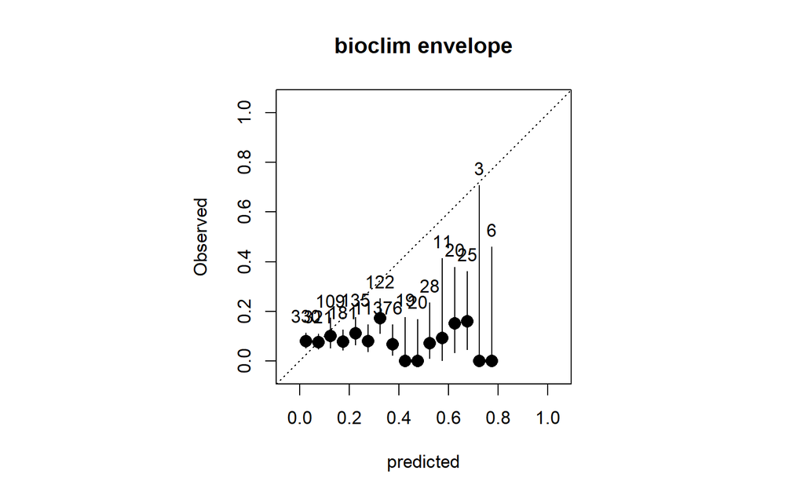

```r
bioC = calibration.plot(valData, which.model=1, N.bins=20, xlab='predicted', ylab='Observed', main='bioclim envelope')
```

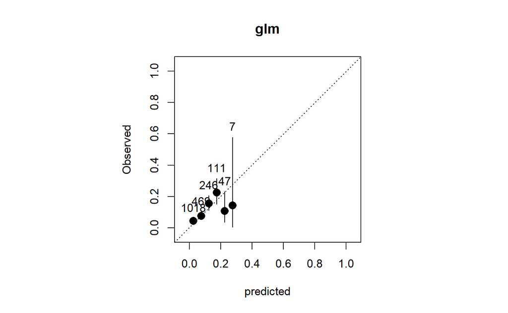

```r
glmC = calibration.plot(valData, which.model=2, N.bins=20, xlab='predicted', ylab='Observed', main='glm')
```

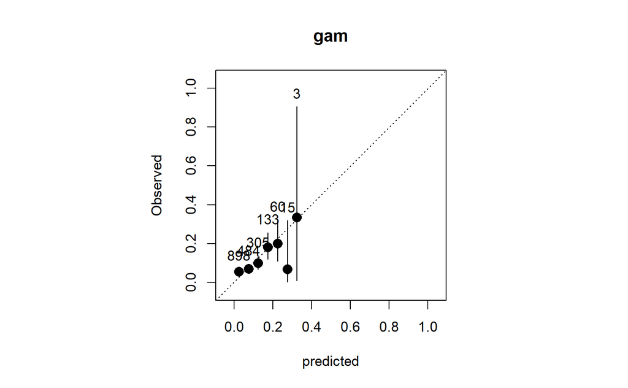

```r
gamC = calibration.plot(valData, which.model=3, N.bins=20, xlab='predicted', ylab='Observed', main='gam')
```

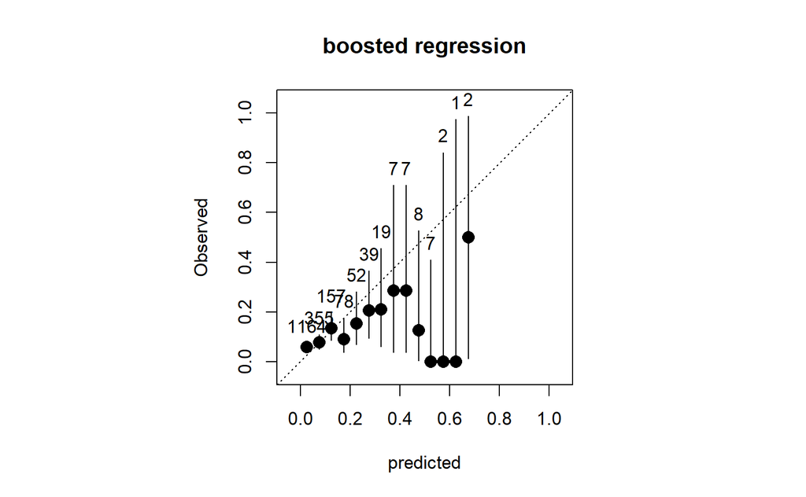

```r
boostC = calibration.plot(valData, which.model=4, N.bins=20, xlab='predicted', ylab='Observed', main='boosted regression')
```

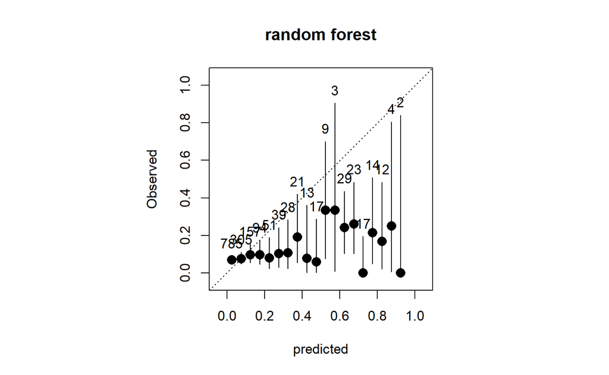

```r
rfC = calibration.plot(valData, which.model=5, N.bins=20, xlab='predicted', ylab='Observed', main='random forest')
```

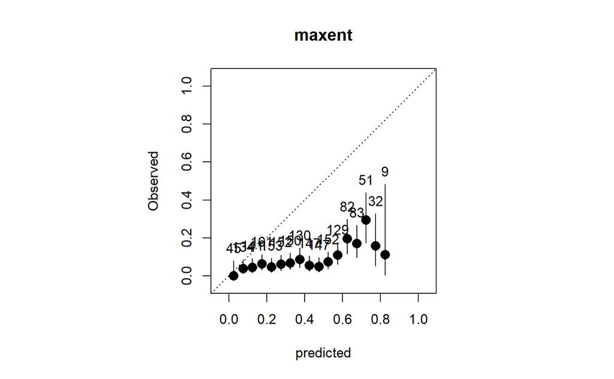

```r
maxentC = calibration.plot(valData, which.model=6, N.bins=20, xlab='predicted', ylab='Observed', main='maxent')
```

**Make a decision (based on your suite of discrimination statistics and calibration plots) about which of your SDMs is “best.” Defend your answer.** I believe that GLM is the best SDM. The kappa values indicate that the glm (k=0.1367) and maxent (k=0.1398)models have a greater agreement than that of expected by chance compared to the competing SDMs. The true skill statistic supports the kappa with glm (tss=0.2741) and maxent (tss=0.2557). The area under the receiver operating characteristic curve for the glm (auc=0.6726) and maxent (auc=0.6599) indicates that over 60% of the time a randomly selected presence location has a greater predicted probability value than a randomly selected absence location. However, both of these AUC values are below the fair range. The calibration plot was useful in identifying GLM as the best model because it appeared to have validation values that fell most closely along the 1-1 line compared to the other SDMs, including the maxent model. The maxent model appeared to predict greater occupancy than that of observed.

# Challenge 2 (4 points)

Each SDM we created uses a different algorithm with different assumptions. Because of this, ecologists frequently use “ensemble” approaches that aggregate predictions from multiple models in some way. Here we are going to create an ensemble model by calculating a weighted average of the predicted occupancy values at each pixel. We will calculate weights based on model AUC values to ensure that the models with the best AUC values have the most influence on the predicted values in the ensemble model.

Create a raster stack that combines the glmMap, gamMap, boostMap, and rfMap (hint use c()).

#### Raster Stack: SDM Models

```r
rsSDMs = c(glmMap, gamMap, boostMap, rfMap)
```

Next, create a vector of the AUC values for each model.

#### AUC Values Combined

```r
AUCs = summaryEval$auc

AUCs = AUCs %>%
    setNames(c('glm', 'gam', 'boost', 'rfMap'))

d = 0.6726221 + 0.6455923 + 0.6403391 + 0.6322577

AUCs = c(0.6726221, 0.6455923, 0.6403391, 0.6322577)/d

AUCs
```

```
[1] 0.2596183 0.2491854 0.2471578 0.2440385
```

Lastly, use the weighted.mean() function in the terra package to create the new raster as a weighted average of the previous 4 rasters.

#### Weighted Average Ensemble Raster

```r
wt = AUCs

AUCwa = weighted.mean(rsSDMs, wt)
```

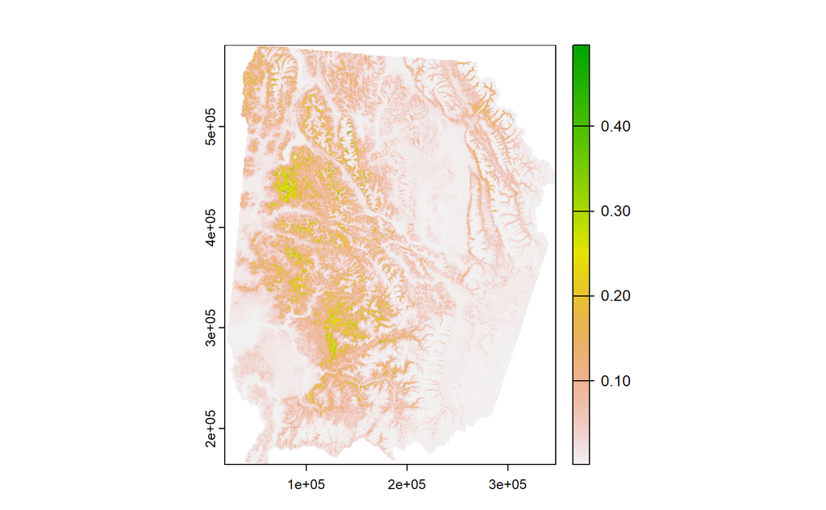

```r
plot(AUCwa)
```

**Explain why we left out the bioclim and Maxent models for this ensemble model.** The bioclim and maxent models have different assumptions and model parameters used in the algorithm compared to SDMs used in the ensemble model. For example, these models are both specifically designed for presence-only data. The AUC method for model descrimination is also likely not best suited for the maxent and bioclim models because it was build for use with presence-absence and not presence-background. Therefore, even though we calculated AUC values for these models, they were not best to use in the ensemble model because they could bias the weighted AUC raster.

# Challenge 3 (4 points)

Is this ensemble model an improvement over one of the models you built previously? Provide evidence and explain the criteria you used to come to your conclusion.

#### Extracting values from model

```r
ensVal = terra::extract(AUCwa, vathValXy)
ensVal
```

| sum |
| --- |
| 0.041115747 |
| 0.033960389 |
| 0.039821710 |
| 0.006507836 |
| 0.005053714 |
| 0.004460537 |
| 0.005616719 |
| 0.004429724 |
| 0.004429724 |
| 0.004571719 |

[output cut: 990 more lines]

```r
NA
```

#### Combining Ensemble Predictions with Previous Models

```r
valData
```

| ID | obs | bioVal | glmVal | gamVal | boostVal | rfVal | maxentVal |
| --- | --- | --- | --- | --- | --- | --- | --- |
| 1 | 0 | 0.01052632 | 5.170890e-02 | 0.0324398383 | 0.035887765 | 0.044 | 0.35721053 |
| 2 | 0 | 0.01052632 | 4.648219e-02 | 0.0300122233 | 0.028698255 | 0.030 | 0.34113100 |
| 3 | 0 | 0.02105263 | 4.161623e-02 | 0.0323459874 | 0.035423939 | 0.050 | 0.30887538 |
| 4 | 0 | 0.02105263 | 1.858345e-03 | 0.0047584268 | 0.013656923 | 0.006 | 0.16588240 |
| 5 | 0 | 0.02105263 | 2.365642e-03 | 0.0056834414 | 0.012232345 | 0.000 | 0.16942469 |
| 6 | 0 | 0.02105263 | 1.433893e-03 | 0.0044848087 | 0.012019544 | 0.000 | 0.14471146 |
| 7 | 0 | 0.02105263 | 1.013211e-03 | 0.0036868785 | 0.012019544 | 0.006 | 0.13540095 |
| 8 | 0 | 0.02105263 | 1.420855e-03 | 0.0043747358 | 0.012019544 | 0.000 | 0.14904571 |
| 9 | 0 | 0.02105263 | 1.420855e-03 | 0.0043747358 | 0.012019544 | 0.000 | 0.14904571 |
| 10 | 0 | 0.02105263 | 1.636751e-03 | 0.0047196382 | 0.012019544 | 0.000 | 0.15360515 |

[output cut: 990 more lines]

```r
ensVald = ensVal[complete.cases(ensVal),]
ensVald = data.frame(ensVald)
ensVald
```

| ensVald |
| --- |
| 0.041115747 |
| 0.033960389 |
| 0.039821710 |
| 0.006507836 |
| 0.005053714 |
| 0.004460537 |
| 0.005616719 |
| 0.004429724 |
| 0.004429724 |
| 0.004571719 |

[output cut: 990 more lines]

```r
AData = cbind(valData, ensVald)
AData
```

| ID | obs | bioVal | glmVal | gamVal | boostVal | rfVal | maxentVal | ensVald |
| --- | --- | --- | --- | --- | --- | --- | --- | --- |
| 1 | 0 | 0.01052632 | 5.170890e-02 | 0.0324398383 | 0.035887765 | 0.044 | 0.35721053 | 0.041115747 |
| 2 | 0 | 0.01052632 | 4.648219e-02 | 0.0300122233 | 0.028698255 | 0.030 | 0.34113100 | 0.033960389 |
| 3 | 0 | 0.02105263 | 4.161623e-02 | 0.0323459874 | 0.035423939 | 0.050 | 0.30887538 | 0.039821710 |
| 4 | 0 | 0.02105263 | 1.858345e-03 | 0.0047584268 | 0.013656923 | 0.006 | 0.16588240 | 0.006507836 |
| 5 | 0 | 0.02105263 | 2.365642e-03 | 0.0056834414 | 0.012232345 | 0.000 | 0.16942469 | 0.005053714 |
| 6 | 0 | 0.02105263 | 1.433893e-03 | 0.0044848087 | 0.012019544 | 0.000 | 0.14471146 | 0.004460537 |
| 7 | 0 | 0.02105263 | 1.013211e-03 | 0.0036868785 | 0.012019544 | 0.006 | 0.13540095 | 0.005616719 |
| 8 | 0 | 0.02105263 | 1.420855e-03 | 0.0043747358 | 0.012019544 | 0.000 | 0.14904571 | 0.004429724 |
| 9 | 0 | 0.02105263 | 1.420855e-03 | 0.0043747358 | 0.012019544 | 0.000 | 0.14904571 | 0.004429724 |
| 10 | 0 | 0.02105263 | 1.636751e-03 | 0.0047196382 | 0.012019544 | 0.000 | 0.15360515 | 0.004571719 |

[output cut: 990 more lines]

```r
NA
```

#### Validation Measurements of Ensemble VS other Models

```r
summaryEval2 = data.frame(matrix(nrow=0, ncol=9))

nModels2 = ncol(AData)-2


for(i in 1:nModels2){

  #AUC
  auc = auc(AData, which.model = i)

  #Find threshold to maximize Kappa
  kappaOpt = optimal.thresholds(AData, which.model = i, opt.methods=3)

  #Sensitivity
  sens = sensitivity(cmx(AData, which.model=i, threshold = kappaOpt[[2]]))

  #Specificity
  spec = specificity(cmx(AData, which.model = i, threshold = kappaOpt[[2]]))

  #True skill statistic
  tss = sens$sensitivity + spec$specificity - 1

  #Kappa
  kappa = Kappa(cmx(AData, which.model = i, threshold = kappaOpt[[2]]))

  #Correlation between predicted and realized values
  corr = cor.test(AData[,2], AData[,i+2])$estimate

  #Log likelihood
  ll = sum(log(AData[,i+2]*AData[,2] + (1-AData[,i+2]) * (1-AData[,2])))
  ll = ifelse(ll == '-Inf', sum(log(AData[,i+2] + 0.01)*AData[,2] + log((1-AData[,i+2]))*(1-AData[,2])), ll)

  #Put them all together and save the values
  summaryI2 = c(i, auc$AUC, corr, ll, kappaOpt[[2]], sens$sensitivity, spec$specificity, tss, kappa[[1]])
  summaryEval2 = rbind(summaryEval2, summaryI2)
}

summaryEval2 = summaryEval2 %>%
  setNames(c('model', 'auc', 'corr', 'll', 'threshold', 'sens', 'spec', 'tss', 'kappa')) %>%
  mutate(model = colnames(AData)[3:9])

summaryEval2
```

| model | auc | corr | ll | threshold | sens | spec | tss | kappa |
| --- | --- | --- | --- | --- | --- | --- | --- | --- |
| bioVal | 0.5830024 | 0.06185483 | -639.2494 | 0.09 | 0.5838926 | 0.5471698 | 0.1310624 | 0.04043921 |
| glmVal | 0.6726221 | 0.17124018 | -520.3501 | 0.09 | 0.5033557 | 0.7707261 | 0.2740818 | 0.13677875 |
| gamVal | 0.6455923 | 0.14414314 | -542.8045 | 0.08 | 0.5906040 | 0.6569468 | 0.2475509 | 0.09325225 |
| boostVal | 0.6403391 | 0.12477095 | -540.9090 | 0.04 | 0.6308725 | 0.5717553 | 0.2026278 | 0.06472780 |
| rfVal | 0.6322577 | 0.12475181 | -598.7629 | 0.09 | 0.4765101 | 0.7106918 | 0.1872019 | 0.08090368 |
| maxentVal | 0.6598862 | 0.15539050 | -996.9272 | 0.54 | 0.4563758 | 0.7993139 | 0.2556897 | 0.13980877 |
| ensVald | 0.6719046 | 0.15855167 | -514.1560 | 0.09 | 0.5167785 | 0.7364208 | 0.2531993 | 0.11539679 |

```r
NA
```

**Is this ensemble model an improvement over one of the models you built previously? Provide evidence and explain the criteria you used to come to your conclusion.** The ensemble model is an improvement over several of the models we previously build in the lab based on the different validaton parameters. However, the GLM model still has a higher AUC score (glm = 0.6726, ens = 6719). While the sensitivity of the ensemble model has a slightly better performance than the golm model (0.5167, 0.50335), the specificity value of the glm outperforms the ensemble model (0.7707,0.7364). Although the models are close, I would overall conclude that the GLM model performs better than the ensemble model based on the TSS and Kappa values (glm performs better in both). These values suggest that the GLM model overall predicts the species distribution better.

# Challenge 4 (4 points)

In the lab we built models using presence-background data then validated those models with presence-absence data. For this challenge, you’re going to compare the predictive ability of a model built using presence-background data with one built using presence-absence data.

Fit a GLM using the presence-background data as we did in the lab (i.e., use the presBackCovs dataframe).

#### Fitting Background GLM

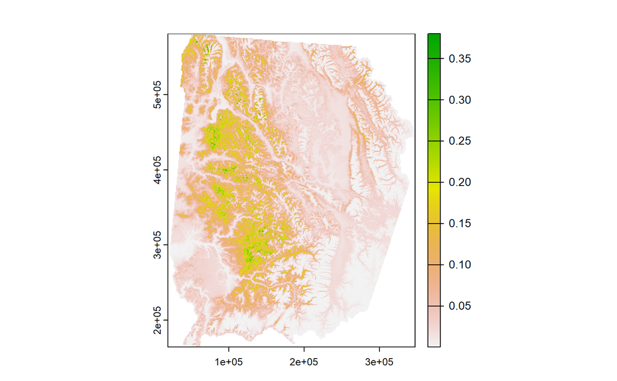

```r
glmBack = glm(pres ~ canopy + elev + I(elev^2) + mesic1km + precip, family='binomial', data=presBackCovs)

glmBackMap = predict(layers, glmBack, type='response')

plot(glmBackMap)
```

Fit a second GLM using the presence-absence data (i.e., use the presAbsCovs dataframe).

#### Fitting Absence GLM

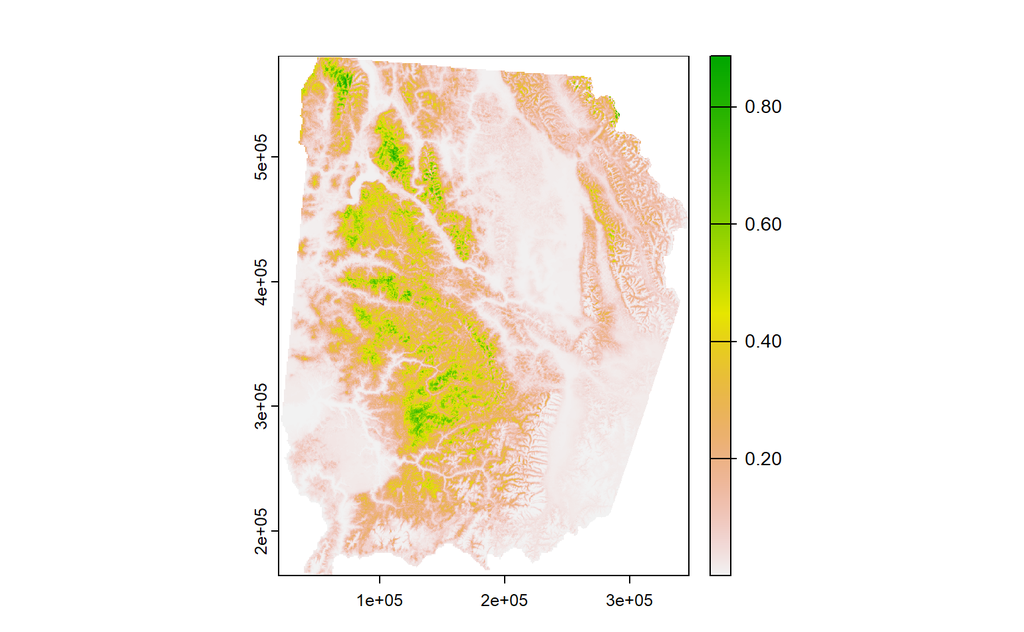

```r
vathData2 = read.csv('https://raw.githubusercontent.com/ValenteJJ/SpatialEcology/main/Week8/vath_2004.csv')

vathPres2 = vathData2 %>% filter(VATH==1)
vathAbs = vathData2 %>% filter(VATH==0)

vathPresXy2 = as.matrix(vathPres2 %>% select(EASTING, NORTHING))
vathAbsXy = as.matrix(vathAbs %>% select(EASTING, NORTHING))

vathVal2 = read.csv('https://raw.githubusercontent.com/ValenteJJ/SpatialEcology/main/Week8/vath_VALIDATION.csv')

vathValPres2 = vathVal2 %>% filter(VATH==1)
vathValAbs = vathVal2 %>% filter(VATH==0)

vathValXy2 = as.matrix(vathVal2 %>% select(EASTING, NORTHING))
vathValPresXy2 = as.matrix(vathValPres2 %>% select(EASTING, NORTHING))
vathValAbsXy = as.matrix(vathValAbs %>% select(EASTING, NORTHING))
presCovs2 = extract(layers, vathPresXy2)
absCovs = extract(layers, vathAbsXy)
valCovs2 = extract(layers, vathValXy2)

presCovs2 = data.frame(vathPresXy2, presCovs2, pres=1)
absCovs = data.frame(vathAbsXy, absCovs, pres=0)
valCovs2 = data.frame(vathValXy2, valCovs2)

presCovs2 = presCovs2[complete.cases(presCovs2),]
absCovs = absCovs[complete.cases(absCovs),]
valCovs2 = valCovs2[complete.cases(valCovs2),]

presAbsCovs = rbind(presCovs2, absCovs)

glmAbs = glm(pres ~ canopy + elev + I(elev^2) + mesic1km + precip, family='binomial', data=presAbsCovs)

glmABMap = predict(layers, glmAbs, type='response')

plot(glmABMap)
```

Validate both of these models on the novel presence-absence data (valCovs dataset). Specifically, calculate and compare AUC, Kappa, and TSS for these two models.